### Air Pollution pm2.5 - 1999 vs 2012[^1]

(C) 2014 Hossein Parsa

In this report we look at the data that comes from the U.S. Environmental Protection Agency and it involves air pollution monitoring data from the United States. In particular we’re looking at fine particulate matter air pollution or pm that is in the air. This is a health concern since we inhale the air and along with that, the particulate matter or dust will be inhaled as well. One of the important pieces of legislation in the last four decades in the United States has been the Clean Air Act. The Clean Air Act has been designed to reduce the levels of air pollution in the United States. So the first question that you might ask is, are air pollution levels lower now than they were before? We’re going to approach answering this question in a very specific way by looking at a fine particle air pollution that was started being measured in 1999 until today. And also answering the question, Are the levels on average lower in 2012 than they were in 1999? Air pollution data in the United States is collected by EPA and is made freely available on their website based on FOIA.

In the following piece of R code we download the files for both 1999 and 2012 years from the website, read and clean the data.

```r
temp <- tempfile()
download.file("http://www.epa.gov/ttn/airs/airsaqs/detaildata/501files/Rd_501_88101_1999.Zip",temp)
pm0 <- read.table(unz(temp, "RD_501_88101_1999-0.txt"), comment.char = "#", header = F, sep = "|", na.string="")
unlink(temp)

temp <- tempfile()
download.file("http://www.epa.gov/ttn/airs/airsaqs/detaildata/501files/RD_501_88101_2012.zip",temp)
pm1 <- read.table(unz(temp, "RD_501_88101_2012-0.txt"), comment.char = "#", header = F, sep = "|", na.string="")
cnames <- readLines(unz(temp, "RD_501_88101_2012-0.txt"), 1)
unlink(temp)

names(pm0) <- make.names(strsplit(cnames, "|", fixed = T)[[1]])
names(pm1) <- names(pm0)
```

Now that the data are available in table format we will take a look at summary of pm measured indicated by sample values in the files.

```r
x0<-pm0$Sample.Value
x1<-pm1$Sample.Value

summary(x0)
```

```
##    Min. 1st Qu.  Median    Mean 3rd Qu.    Max.    NA's
##    0.00    7.20   11.50   13.74   17.90  157.10   13217
```

```r
summary(x1)
```

```
##    Min. 1st Qu.  Median    Mean 3rd Qu.    Max.    NA's
##  -10.00    4.00    7.80    9.43   12.20  985.00  176732
```

In the 1999 data, the median’s about 11.5. So there does appear on average to be decreasing in the levels for the whole country in pm 2.5 considering the following missing values ratio.

```r
mean(is.na(x0))
```

```
## [1] 0.1125608
```

```r
mean(is.na(x1))
```

```
## [1] 0.07294746
```

We also noticed in the summary of 2012 data that there is negative values. negative values basically cannot be correct because pm is the measure of mass which cannot be negative. We create a logical vector depending on the measured value being below zero.

```r
negative <- x1<0
```

For the year 2012 there are 51923 records or 2.31 percent of the entire data set having negative value. Capturing negative values might have happened at certain time of the year. To look into that we’ll extract the dates first.

```r
dates<-pm1$Date
dates<-as.Date(as.character(dates), "%Y%m%d")
```

And then plotting the dates by month:

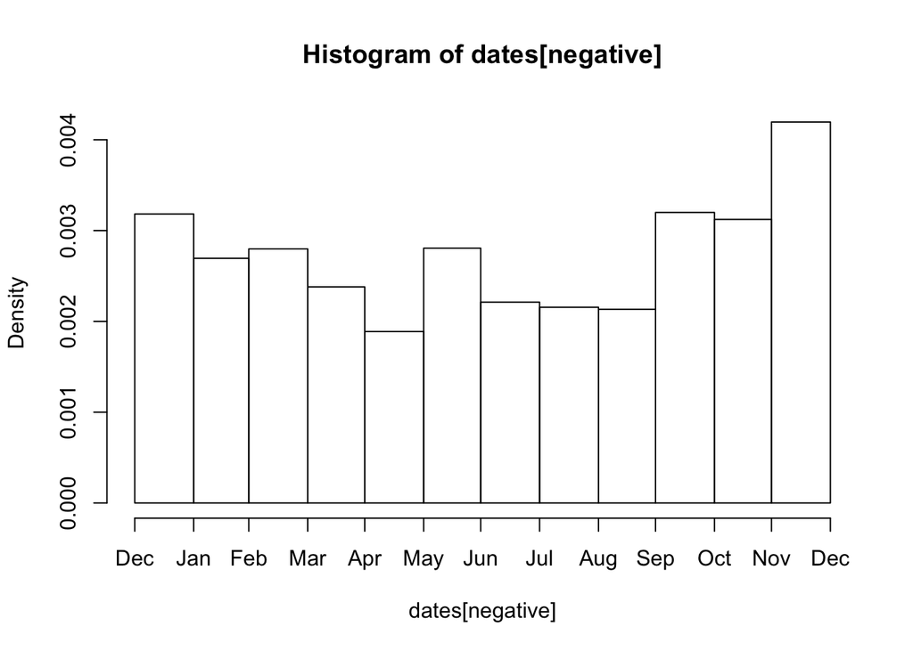

It seems negative values are more often in colder months of the year. To have a more consistent view of the data, we’ll take a look at monitoring sites at only one site in one county and in one state, e.g New York with state code of 36, county code of 63 and site code of 2008. Then compare the records of the sites that exist in both years, 1999 and 2012.

```r
pm1sub <- subset(pm1, State.Code == 36 & County.Code == 63 & Site.ID == 2008)
pm0sub <- subset(pm0, State.Code == 36 & County.Code == 63 & Site.ID == 2008)
```

1999 data

```r
dates0 <- pm0sub$Date
dates0 <- as.Date(as.character(dates0), "%Y%m%d")
x0sub <- pm0sub$Sample.Value
```

2012 data

```r
dates1 <- pm1sub$Date
dates1 <- as.Date(as.character(dates1), "%Y%m%d")
x1sub <- pm1sub$Sample.Value
```

Finding the global range and plotting both data

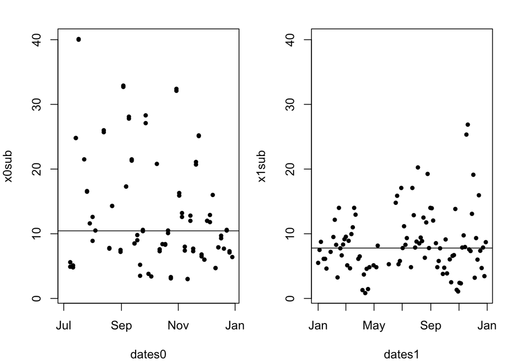

```r
rng <- range(x0sub, x1sub, na.rm = T)
par(mfrow = c(1, 2), mar = c(4, 4, 2, 1))
plot(dates0, x0sub, pch = 20, ylim = rng)
abline(h = median(x0sub, na.rm = T))
plot(dates1, x1sub, pch = 20, ylim = rng)
abline(h = median(x1sub, na.rm = T))
```

Now we’ll show state-wide means and make a plot showing trends.

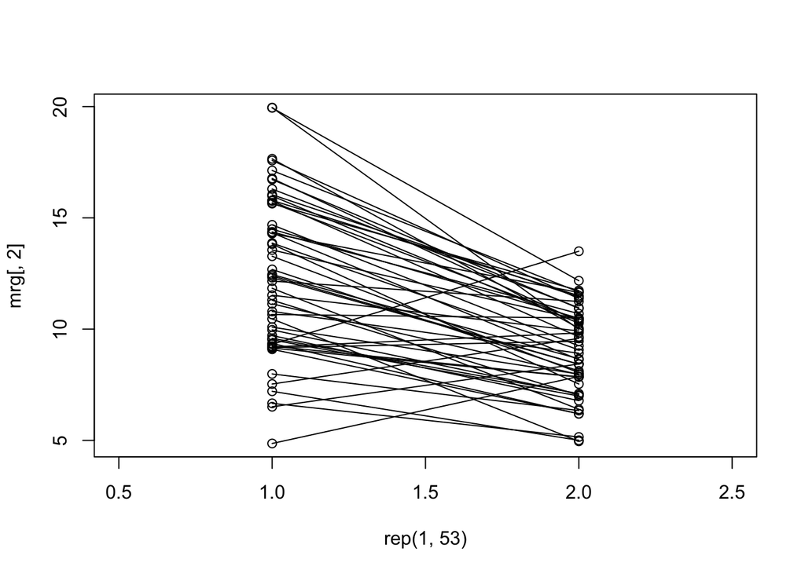

```r
mn0 <- with(pm0, tapply(Sample.Value, State.Code, mean, na.rm = T))
mn1 <- with(pm1, tapply(Sample.Value, State.Code, mean, na.rm = T))
d0 <- data.frame(state = names(mn0), mean = mn0)
d1 <- data.frame(state = names(mn1), mean = mn1)
mrg <- merge(d0, d1, by = "state")
par(mfrow = c(1, 1))
with(mrg, plot(rep(1, 53), mrg[, 2], xlim = c(.5, 2.5)))
with(mrg, points(rep(2, 53), mrg[, 3]))
segments(rep(1, 53), mrg[, 2], rep(2, 53), mrg[, 3])
```

And as the plot displays, for the most part, states show a decreasing trend of particular matter from 1999 to 2012.

to summarize the basic question, we were trying if particular matter levels have decreased between 1999 and 2012. We first looked at the data for the entire country between 1999 and 2012. Then we tried to explore the trend for an individual monitor between those two time periods, and we also looked at it for individual states. Through a combination of data summaries and plots, we could get an exploratory view at the data and see what kind of other questions we can continue to ask.

[^1]: This data exploration is mainly the work of Dr. Peng available on [Coursera](https://www.coursera.org/course/exdata)